# Generating random numbers

Author

Hans Elliott

```r
set.seed(123)
library(data.table)
library(ggplot2)
library(patchwork)
```

These notes pull from these sources:

- Simon Wood has a [course on statistical programming](https://statprog-s1-2020.github.io/) and a related appendix in his Core Statistics book on random number generation.

A computer cannot actually produce random numbers, but thanks to some math we can produce what are often called **pseudo-random numbers** - which are sequences of numbers that are actually *completely deterministic* but that appear indistinguishable from a random sequence with respect to statistical properties that we want to test.

It turns out that we can produce pseudo-random numbers from most distributions by first generating pseudo-random numbers for a $\text{Uniform}(0, 1)$, since once we have a stream of i.i.d. $U(0,1)$ deviates we can use the inverse CDF to map them to deviates from other distributions.

This is an intuitive idea, but in *Core Statistics*, Wood writes that there are better methods than inversion for most standard distributions - with the exception of the exponential. As a result, the inversion method is generally not what R is doing under the hood.

## Simulating random numbers by inversion

For example, imagine we want to generate a random number from a $\text{Normal}(0, 1)$ distribution and we don’t have access to the `rnorm` function (which would do just that), but we do have access to the `runif` function which generates random numbers from a $\text{Uniform}(a,b)$ distribution, $\text{U}(0,1)$ by default.

Generating a $\text{U}(0,1)$ deviate guarantees a number between $0$ and $1$, which we can then treat as a probability.

Recall that a random variable $X$ has a cumulative distribution function (CDF) that gives the $P(X \leq x)$, where $x$ is a particular value, or “quantile”.

So $x$ can be any value that is possible for the random variable $X$, and the CDF maps $x$ to a probability, of course between $0$ and $1$, suggesting that if we could inverse this mapping to go from a probability to a value of $x$, then we could convert a $U(0,1)$ deviate into a deviate from $X$’s distribution.

Indeed a straightforward strategy is to sample a value $u$ from $U(0,1)$ and pass the value through the inverse CDF, or the “quantile function”.

This is visualized clearly by the figure below. The black line represents the CDF of a $\text{Normal}(0, 1)$ distribution, often called $\Phi$. The red points represent a few random samples from a $\text{U}(0,1)$ distribution, and the red dashed lines show where these points meet the CDF. The blue dashed lines show where the inverse CDF, $\Phi^{-1}$, maps these points.

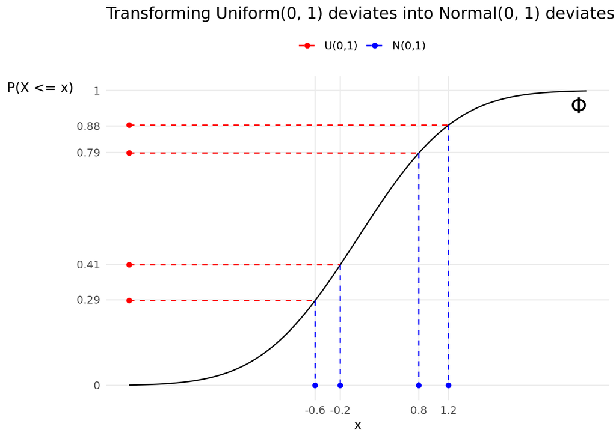

```r
## randomly sample a few uniform(0,1) deviates,
## which represent a random choice of probability that X <= x, for r.v. X
unif_sample <- data.frame(
  x = -3,
  u = runif(n = 4, min = 0, max = 1)
)
unif_sample$group <- 1:nrow(unif_sample)

## to draw lines to the CDF, calculate where on the x-axis the uniform deviates
##    meet the CDF, using the quantile function/inverse CDF
unif_endpoints <- data.frame(
  x = qnorm(unif_sample$u),
  u = unif_sample$u,
  group = unif_sample$group
)

## to draw where the inverse of the CDF maps the uniform deviates:
xax_points <- data.frame(
  x = unif_endpoints$x,
  u = 0,
  group = unif_endpoints$group
)

## to draw a Normal(0, 1) CDF over a range of possible x values
xval <- seq(unif_sample$x[1], abs(unif_sample$x[1]), length.out = 1000)
gauss_cdf <- data.frame(
  x = xval,
  y = pnorm(xval, mean = 0, sd = 1) ## CDF
)

ybr <- c(0, round(unif_sample$u, 2), 1)
ggplot(gauss_cdf, aes(x = x, y = y)) +
  geom_line() +
  geom_point(data = unif_sample, aes(x = x, y = u, color = "U(0,1)")) +
  geom_line(data = rbind(unif_sample, unif_endpoints),
            aes(x = x, y = u, group = group, color = "U(0,1)"),
            linetype = 2) +
  geom_line(data = rbind(unif_endpoints, xax_points),
            aes(x = x, y = u, group = group, color = "N(0,1)"),
            linetype = 2) +
  geom_point(data = xax_points, aes(x = x, y = u, color = "N(0,1)")) +
  annotate("text", x = 2.9, y = 0.95, label = expression(Phi), size = 6) +
  scale_x_continuous(labels = round(xax_points$x, 1), breaks = xax_points$x) +
  scale_y_continuous(labels = ybr, breaks = ybr) +
  scale_color_manual(breaks = c("U(0,1)", "N(0,1)"),
                     values = c("red", "blue")) +
  labs(
    title = "Transforming Uniform(0, 1) deviates into Normal(0, 1) deviates",
    x = "x",
    y = "P(X <= x)",
    color = ""
  ) +
  theme_minimal() +
  theme(
    legend.position = "top",
    panel.grid.minor = element_blank(),
    axis.title.y = element_text(angle = 0, vjust = 0.98),
  )
```

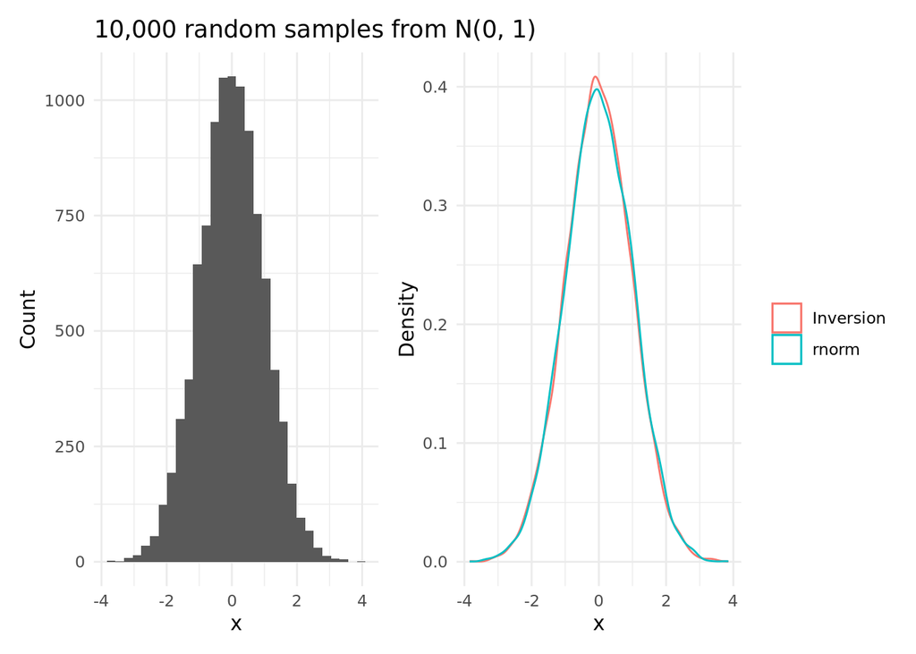

```r
X <- qnorm(runif(10000))
Xr <- rnorm(10000)

p1 <- ggplot(data.frame(X = X), aes(x = X)) +
  geom_histogram() +
  labs(
    title = "10,000 random samples from N(0, 1)",
    x = "x",
    y = "Count"
  ) +
  theme_minimal()

p2 <- ggplot() +
  geom_density(aes(x = X, color = "Inversion")) +
  geom_density(aes(x = Xr, color = "rnorm")) +
  labs(
    x = "x",
    y = "Density",
    color = ""
  ) +
  theme_minimal()

p1 + p2
```

For discrete random variables, we can use the “generalized inverse” for CDF $F$ defined as:
$$F^{-1}(u) = \inf\{x \in \mathbb{R} : F(x) \geq u\}$$
since for a $\text{Uniform}(0,1)$ deviate $U$, $\mathbb{P}(F^{-1}(U) \le x) = \mathbb{P}(U \le F(x))$.
This corresponds to obtaining the smallest $x$ such that $F(x)$ is greater than or equal to the value $u$.

Looking at the figure below, the black lines represent the discrete CDF of the Poisson distribution with parameter $\lambda = 5$. Again, the red points are random $U(0,1)$ deviates and the $blue$ points show the corresponding Poisson deviates.

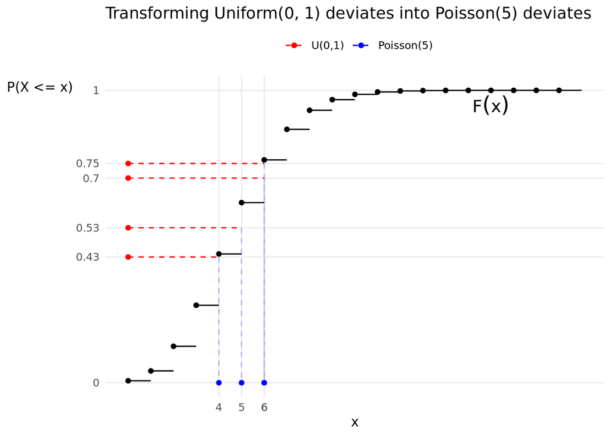

```r
lambda <- 5

## poisson cdf
xval <- rep(0:20, each = 2)[-1]
xval <- xval[-length(xval)]
poisson_cdf <- data.frame(
  x = xval,
  y = ppois(xval, lambda = lambda),
  group = rep(1:(length(xval)/2), each = 2)
)
## horizontal line points
poisson_cdf <- within(poisson_cdf, {
  yshift <- shift(y, 1, type = "lag")
  yhoriz <- y
  repix <- seq(2, nrow(poisson_cdf), by = 2)
  yhoriz[repix] <- yshift[repix]
})
## vertical line points
poisson_cdf$xshift <- shift(poisson_cdf$x, 1, type = "lead")

## uniform deviates
unif_sample <- data.frame(
  x = 0,
  # p = runif(n = 4, min = 0, max = 1)
  ## choose for sake of example
  u = c(0.43, 0.53, 0.7, 0.75)
)
unif_sample$group <- 1:nrow(unif_sample)

unif_endpoints <- data.frame(
  x = qpois(unif_sample$u, lambda = lambda),
  u = unif_sample$u,
  group = unif_sample$group
)
xax_points <- data.frame(
  x = unif_endpoints$x,
  u = 0,
  group = unif_endpoints$group
)


ggplot() +
  # cdf
  geom_line(data = poisson_cdf,
            aes(x = x, y = yhoriz, group = group)) +
  geom_point(data = poisson_cdf[seq(1, nrow(poisson_cdf), by = 2), ],
             aes(x = x, y = yhoriz)) +
  ## geom_line(data = poisson_cdf,
  ##            aes(x = xshift, y = y, group = group),
  ##           linetype = "dashed") +
  # uniform deviates
  geom_point(data = unif_sample, aes(x = x, y = u, color = "U(0,1)")) +
  # connecting lines
  geom_line(data = rbind(unif_sample, unif_endpoints),
            aes(x = x, y = u, group = group, color = "U(0,1)"),
            linetype = 2) +
  geom_line(data = rbind(unif_endpoints, xax_points),
            aes(x = x, y = u, group = group, color = "Poisson(5)"),
            linetype = 2, alpha = 0.25) +
  # poisson deviates
  geom_point(data = xax_points, aes(x = x, y = u, color = "Poisson(5)")) +
  # aesthetics
  annotate("text", x = 16, y = 0.95, label = expression(F(x)), size = 5) +
  scale_x_continuous(labels = round(xax_points$x, 1), breaks = xax_points$x) +
  scale_y_continuous(labels = round(c(0, unif_sample$u, 1), 2),
                     breaks = c(0, unif_sample$u, 1)) +
  scale_color_manual(breaks = c("U(0,1)", "Poisson(5)"),
                     values = c("red", "blue")) +
  labs(
    title = "Transforming Uniform(0, 1) deviates into Poisson(5) deviates",
    x = "x",
    y = "P(X <= x)",
    color = ""
  ) +
  theme_minimal() +
  theme(
    legend.position = "top",
    panel.grid.minor = element_blank(),
    axis.title.y = element_text(angle = 0, vjust = 0.98),
  )
```

So pick a random number between $0$ and $1$ - say $0.53$. Next we need to calculate $F^{-1}(0.53)$ to obtain a Poisson deviate.  
According to the definition of the generalized inverse, this value will be the smallest $x$ such that $F(x) >= 0.53$.  
We can see that at $x = 5$, the CDF $F(x)$ jumps from about $0.44$ to about $0.62$, where it remains until $x = 6$. So the $\text{Poisson}(5)$ deviate corresponding to probability $0.53$ is $x = 5$.

```r
ppois(4, lambda = 5)
```

```
[1] 0.4404933
```

```r
ppois(5, lambda = 5)
```

```
[1] 0.6159607
```

## Generating uniform deviates

At a basic level, we want a pseudo-random number generator that produces a sequence of numbers that are uncorrelated, so that the generated sequence models an i.i.d. sequence of $U(0,1)$ deviates very well.

One common method is called the *linear congruential generator* (LCG), where the sequence is defined as:
$$X_{i+1} = (a X_i + b) \mod M$$

The idea is to take some integer, multiply it by some very large constant, rewrite it using some large base $M$, and throw away everything except for what comes after the decimal to use as a new integer.

For example:
$$X_{i+1} = (69069 X_{i} + 1) \mod 2^{32}$$

is considered to be one of the better simple congruential generators.

The first integer $X_0$ is called the “seed”, and determines where in the sequence we start.

Here is an example of an LCG with poorly chosen parameters. In 1 dimension it looks random, but comparing triples of points $(U_{i}, U_{i-1}, U_{i-2})$ shows that the deviates are not uniformly distributed in 3 dimensions.

```r
# linear congruential generator
lcg <- function(n, a = 69069, b = 1, M = 2^32, seed = 1) {
  x <- numeric(n)
  x[1] <- seed
  if (n == 1)
    return(((a * x + b) %% M) / M)
  for (i in 2:n) {
    x[i] <- (a * x[i - 1] + b) %% M
  }
  x / M
}

n <- 100000
U <- lcg(n, a = 65539, b = 0)
```

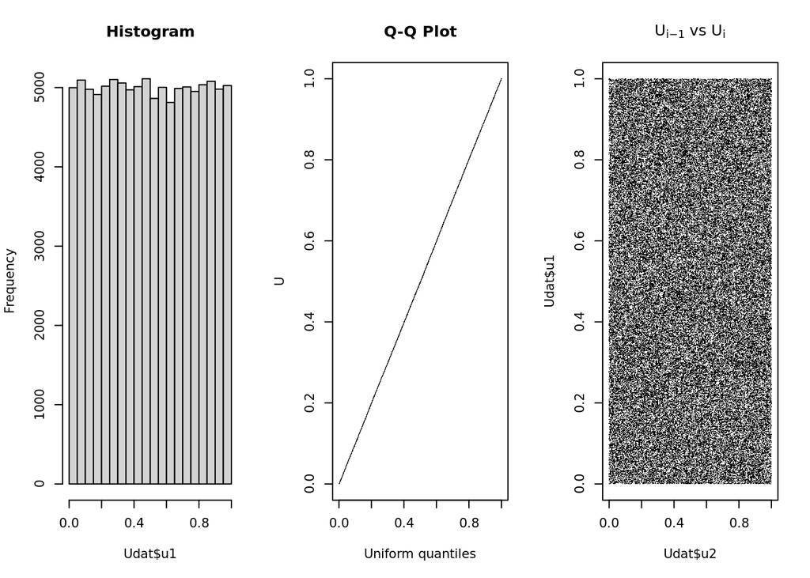

```r
Udat <- data.frame(u1=U[1:(n-2)],u2=U[2:(n-1)],u3=U[3:n])

## looks random enough
par(mfrow = c(1, 3))
hist(Udat$u1, main = "Histogram")
qqplot((1:1000)/1000, sort(Udat$u1),
       pch = ".", xlab = "Uniform quantiles", ylab = "U", main = "Q-Q Plot")
plot(Udat$u2, Udat$u1, pch = ".",
     main = expression(U[i-1] ~ "vs" ~ U[i]))
```

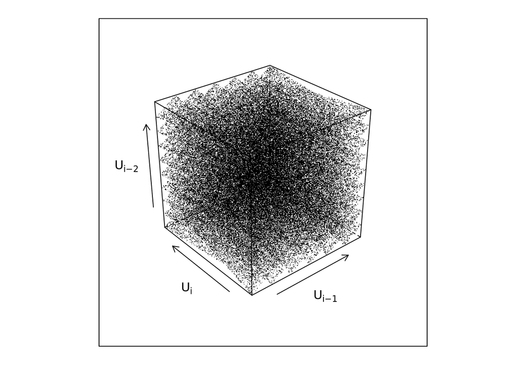

```r
lattice::cloud(
  u1 ~ u2 * u3,
  data = Udat,
  pch = ".",
  col = 1,
  screen = list(z = 40, x = -60, y = 0),
  zlab = expression(U[i-2]),
  xlab = expression(U[i-1]),
  ylab = expression(U[i])
)
```

Using the better parameters $a = 69069$ and $b=1$ gives:

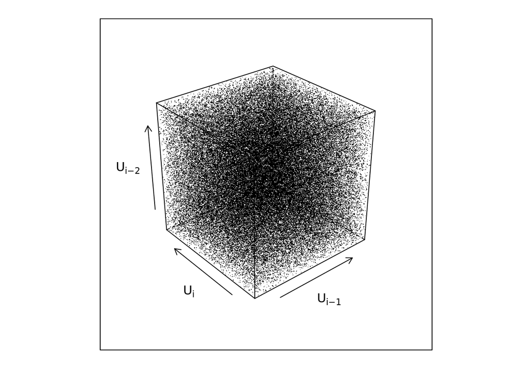

```r
n <- 100000
U <- lcg(n, a = 69069, b = 1)
Udat <- data.frame(u1=U[1:(n-2)],u2=U[2:(n-1)],u3=U[3:n])

lattice::cloud(
  u1 ~ u2 * u3,
  data = Udat,
  pch = ".",
  col = 1,
  screen = list(z = 40, x = -60, y = 0),
  zlab = expression(U[i-2]),
  xlab = expression(U[i-1]),
  ylab = expression(U[i])
)
```

Alternative to congruential generators are those that generate random sequences of 0s and 1s, sometimes called shift-register generators.

The popular *Mersenne Twister* generator is of this type. It is the default in R, and recommended as a general purpose generator.

```r
base::RNGkind(kind = "default")
base::RNGkind()[1]
```

```
[1] "Mersenne-Twister"
```

Example implementation here:  
https://github.com/ESultanik/mtwister